# Figure_1:_Heatmap_and_GSEA

2024-04-18

## Dataset background

The data being analyzed in this project is a bulk RNA-seq of 8 different human tumor samples.These samples were surgically removed from various patients with hepatocellular carcinoma (HCC) primary liver cancer. These samples are divided into 2 groups, tumors that were able to successfully form tumor organoids and those that could not, with 4 biological replicates for each. The goal of this analysis is to determine what molecular mechanisms differ between successful and failed tumor samples

Raw RNA-seq data can be found with the SRA accession PRJNA841062 and is sourced from the following scientific paper:

Xian, L., Zhao, P., Chen, X., Wei, Z., Ji, H., Zhao, J., Liu, W., Li, Z., Liu, D., Han, X., Qian, Y., Dong, H., Zhou, X., Fan, J., Zhu, X., Yin, J., Tan, X., Jiang, D., Yu, H., & Cao, G. (2022). Heterogeneity, inherent and acquired drug resistance in patient-derived organoid models of primary liver cancer. Cellular oncology (Dordrecht), 45(5), 10191036. https://doi.org/10.1007/s13402-022-00707-3

### Load the required libraries

The following libraries are necessary for data analysis and visualization.

```r
library(knitr)
library(DESeq2)
library(RColorBrewer)
library(pheatmap)
library(ggplot2)
library(tidyverse)
library(cowplot)
library(tidyr)
library(dplyr)
library(patchwork)
library(ggplotify)
library(clusterProfiler)
library(msigdbr)
library(pathview)
library(enrichplot)
library(msigdbr)
library(GSEABase)
library(genekitr)
library(org.Hs.eg.db)
library(DOSE)
library(ggnewscale)
```

### htseq-count input

```r
#load annotation file
sampleTable <- read.csv("PRJNA841062_HCC_anno.csv", header = TRUE)
sampleTable <- data.frame(sampleTable)
head(sampleTable)
```

```
##   samplename           filename presentation
## 1      HCC_1   HCC_1.ENSG.count      Failure
## 2    HCC_125 HCC_125.ENSG.count      Failure
## 3    HCC_101 HCC_101.ENSG.count      Failure
## 4    HCC_109 HCC_109.ENSG.count      Failure
## 5    HCC_118 HCC_118.ENSG.count      Success
## 6     HCC_25  HCC_25.ENSG.count      Success
```

The “presentation” column is specified as a factor by first creating a ‘presentation’ object (allowing categorization of data).

```r
#specify the presentation column as factor
presentation <- factor(sampleTable$presentation)
```

## Running DESeq2 with DESeqDataSet

The design is set as ‘~presentation’, where the presentation is identified as the distinguishing parameter in data comparison. ‘dds’ is created as the DESEQ2 object

```r
# perform DESeqDataSet
dds <- DESeqDataSetFromHTSeqCount(sampleTable = sampleTable,
                                  directory = ".",
                                  design = ~presentation)
dds
```

```
## class: DESeqDataSet
## dim: 69222 8
## metadata(1): version
## assays(1): counts
## rownames(69222): ENSG00000000003.15 ENSG00000000005.6 ...
##   ENSG00000291316.1 ENSG00000291317.1
## rowData names(0):
## colnames(8): HCC_1 HCC_125 ... HCC_10 HCC_52
## colData names(1): presentation
```

### Pre-filtering

Prefiltering is performed to filter out any insignificant rows that have less than 10 reads. A new object is created for this filtering.

```r
#filter out insignificant data
keep <- rowSums(counts(dds)) >= 10
dds <- dds[keep,]
```

The reference level is identified as the ‘Failure’ presentation group, which will be considered the control group by R.

```r
dds$presentation <- relevel(dds$presentation, ref = "Failure")
```

The DESEQ2 Object is saved/loaded as RDS file

```r
# saveRDS(dds, file = "dds.rds")
# load RDS file of dds if necessary
dds <- readRDS("dds.rds")
```

### Differential expression analysis

Differential expression analysis is conducted using ‘DESeq()’.

```r
#perform differentioal expression analysis
DESeq_dds <- DESeq(dds)
```

Differential expression analysis output is saved/loaded as RDS file

```r
#saveRDS(DESeq_dds, file = "DESeq_dds.rds")
# load RDS file if necessary
DESeq_dds <- readRDS("DESeq_dds.rds")
```

The results of the analysis are extracted in a tabular format into a new object, with a comparison between the two presentation groups. Interpretations of the table columns are as follows: ‘baseMean’ = average of normalized counts of specific gene across all samples ‘log2FoldChange’ = log 2 fold change between the Success and Failure groups of HCC organoids ‘pvalue’ = P value (from Wald test) ‘padj’ = P adjusted value (Benjamini-Hochberg adjusted)

```r
#extract results from DESeq
DESeq_result <- results(DESeq_dds, contrast = c("presentation", "Success", "Failure"))
head(DESeq_result)
```

```
## log2 fold change (MLE): presentation Success vs Failure
## Wald test p-value: presentation Success vs Failure
## DataFrame with 6 rows and 6 columns
##                     baseMean log2FoldChange     lfcSE      stat      pvalue
##                    <numeric>      <numeric> <numeric> <numeric>   <numeric>
## ENSG00000000003.15 2624.8871      -0.415806  0.491689 -0.845669 0.397737253
## ENSG00000000005.6     2.3538      -3.122146  2.335452 -1.336849 0.181272018
## ENSG00000000419.14 1550.9591       0.497281  0.383389  1.297067 0.194608247
## ENSG00000000457.14  618.2154      -0.364450  0.543778 -0.670218 0.502718570
## ENSG00000000460.17  353.3706       0.447382  0.382170  1.170638 0.241744226
## ENSG00000000938.13 1077.7274       2.421342  0.626762  3.863259 0.000111884
##                          padj
##                     <numeric>
## ENSG00000000003.15 0.74283710
## ENSG00000000005.6          NA
## ENSG00000000419.14 0.54942984
## ENSG00000000457.14 0.80791547
## ENSG00000000460.17 0.60408150
## ENSG00000000938.13 0.00677819
```

The results are sorted by P adjusted values and placed in a table

```r
#sort by padj
DESeq_sorted_result <- DESeq_result [order(DESeq_result $padj), ]
head(DESeq_sorted_result)
```

```
## log2 fold change (MLE): presentation Success vs Failure
## Wald test p-value: presentation Success vs Failure
## DataFrame with 6 rows and 6 columns
##                     baseMean log2FoldChange     lfcSE      stat      pvalue
##                    <numeric>      <numeric> <numeric> <numeric>   <numeric>
## ENSG00000266964.6    137.612       -6.96926  0.671256 -10.38243 2.98102e-25
## ENSG00000174358.16  1066.969       12.08246  1.289632   9.36892 7.32776e-21
## ENSG00000019169.11   592.666        6.89127  0.778820   8.84836 8.88171e-19
## ENSG00000073734.10   541.499       -5.87127  0.683452  -8.59062 8.65002e-18
## ENSG00000183549.10  1676.780       -4.81096  0.561967  -8.56093 1.11960e-17
## ENSG00000106541.12  5203.983       10.16415  1.279555   7.94350 1.96554e-15
##                           padj
##                      <numeric>
## ENSG00000266964.6  6.26670e-21
## ENSG00000174358.16 7.70220e-17
## ENSG00000019169.11 6.22371e-15
## ENSG00000073734.10 4.54602e-14
## ENSG00000183549.10 4.70724e-14
## ENSG00000106541.12 6.88658e-12
```

```r
table(DESeq_sorted_result$padj<0.05)
```

```
##
## FALSE  TRUE
## 19943  1079
```

The sorted results are saved/loaded as RDS file

```r
#saveRDS(DESeq_sorted_result, file = "DESeq_sorted_result.rds")
# load RDS file if necessary
DESeq_sorted_result <- readRDS("DESeq_sorted_result.rds")
```

The DESeq results are merged with the counts data. The first column is also renamed with the Gene IDs.

```r
#merge counts and DESeq
resdata <- merge(as.data.frame(DESeq_sorted_result), as.data.frame(counts(DESeq_dds, normalized=TRUE)), by="row.names", sort=FALSE)
names(resdata)[1] <- "Gene_id"
head(resdata)
```

```
##              Gene_id  baseMean log2FoldChange     lfcSE       stat       pvalue
## 1  ENSG00000266964.6  137.6119      -6.969261 0.6712556 -10.382426 2.981022e-25
## 2 ENSG00000174358.16 1066.9688      12.082459 1.2896319   9.368921 7.327756e-21
## 3 ENSG00000019169.11  592.6665       6.891274 0.7788197   8.848357 8.881707e-19
## 4 ENSG00000073734.10  541.4995      -5.871274 0.6834516  -8.590621 8.650017e-18
## 5 ENSG00000183549.10 1676.7798      -4.810957 0.5619666  -8.560931 1.119598e-17
## 6 ENSG00000106541.12 5203.9835      10.164150 1.2795554   7.943501 1.965536e-15
##           padj       HCC_1    HCC_125     HCC_101     HCC_109     HCC_118
## 1 6.266704e-21  206.358710  336.43623  195.103552  353.728185    0.811056
## 2 7.702204e-17    0.000000    0.00000    0.000000    1.618893 1231.182993
## 3 6.223708e-15    6.094983   11.50966    3.363854   17.807826  466.357194
## 4 4.546017e-14  622.558977 1158.93427 1283.310433 1193.124358   13.787952
## 5 4.707238e-14 1749.260117 2362.13646 4305.733562 4534.520119   48.663359
## 6 6.886584e-12    4.353559   27.44611    1.681927    2.428340 1180.897522
##        HCC_25       HCC_10       HCC_52
## 1    2.870737     3.917407     1.669219
## 2 4330.028455   425.691546  2547.228247
## 3  656.441883   680.322992  2899.433463
## 4    9.569124    45.703080     5.007657
## 5  116.743309   203.705157    93.476266
## 6  162.675102 14652.407463 25599.977727
```

The results are written as a new file.

```r
write.csv(resdata, file = "HCCSuccessvsFailure_ unfiltered_matrix.csv")
```

### DEGs are filtered by significance

A list of differentially expressed genes are acquired from the previous data. These DEGs are filtered by a p adjusted value of < 0.05 and a log 2 fold change of 1.

```r
#filter out insignificant data by padj and log2FC
resdata <- as.data.frame(resdata) %>% dplyr::filter(abs(log2FoldChange) > 1 & padj < 0.05)
head(resdata)
```

```
##              Gene_id  baseMean log2FoldChange     lfcSE       stat       pvalue
## 1  ENSG00000266964.6  137.6119      -6.969261 0.6712556 -10.382426 2.981022e-25
## 2 ENSG00000174358.16 1066.9688      12.082459 1.2896319   9.368921 7.327756e-21
## 3 ENSG00000019169.11  592.6665       6.891274 0.7788197   8.848357 8.881707e-19
## 4 ENSG00000073734.10  541.4995      -5.871274 0.6834516  -8.590621 8.650017e-18
## 5 ENSG00000183549.10 1676.7798      -4.810957 0.5619666  -8.560931 1.119598e-17
## 6 ENSG00000106541.12 5203.9835      10.164150 1.2795554   7.943501 1.965536e-15
##           padj       HCC_1    HCC_125     HCC_101     HCC_109     HCC_118
## 1 6.266704e-21  206.358710  336.43623  195.103552  353.728185    0.811056
## 2 7.702204e-17    0.000000    0.00000    0.000000    1.618893 1231.182993
## 3 6.223708e-15    6.094983   11.50966    3.363854   17.807826  466.357194
## 4 4.546017e-14  622.558977 1158.93427 1283.310433 1193.124358   13.787952
## 5 4.707238e-14 1749.260117 2362.13646 4305.733562 4534.520119   48.663359
## 6 6.886584e-12    4.353559   27.44611    1.681927    2.428340 1180.897522
##        HCC_25       HCC_10       HCC_52
## 1    2.870737     3.917407     1.669219
## 2 4330.028455   425.691546  2547.228247
## 3  656.441883   680.322992  2899.433463
## 4    9.569124    45.703080     5.007657
## 5  116.743309   203.705157    93.476266
## 6  162.675102 14652.407463 25599.977727
```

The results are written as a new file.

```r
write.csv(resdata, file = "HCCSuccessvsFailure_ filtered_matrix.csv")
```

Padj threshold and vector are added to results table.

```r
#significant padj adjustment
threshold_padj <- resdata$padj < 0.05
length(which(threshold_padj))
```

```
## [1] 1053
```

```r
resdata$threshold <- threshold_padj
str(resdata)
```

```
## 'data.frame':    1053 obs. of  16 variables:
##  $ Gene_id       : 'AsIs' chr  "ENSG00000266964.6" "ENSG00000174358.16" "ENSG00000019169.11" "ENSG00000073734.10" ...
##  $ baseMean      : num  138 1067 593 541 1677 ...
##  $ log2FoldChange: num  -6.97 12.08 6.89 -5.87 -4.81 ...
##  $ lfcSE         : num  0.671 1.29 0.779 0.683 0.562 ...
##  $ stat          : num  -10.38 9.37 8.85 -8.59 -8.56 ...
##  $ pvalue        : num  2.98e-25 7.33e-21 8.88e-19 8.65e-18 1.12e-17 ...
##  $ padj          : num  6.27e-21 7.70e-17 6.22e-15 4.55e-14 4.71e-14 ...
##  $ HCC_1         : num  206.36 0 6.09 622.56 1749.26 ...
##  $ HCC_125       : num  336.4 0 11.5 1158.9 2362.1 ...
##  $ HCC_101       : num  195.1 0 3.36 1283.31 4305.73 ...
##  $ HCC_109       : num  353.73 1.62 17.81 1193.12 4534.52 ...
##  $ HCC_118       : num  0.811 1231.183 466.357 13.788 48.663 ...
##  $ HCC_25        : num  2.87 4330.03 656.44 9.57 116.74 ...
##  $ HCC_10        : num  3.92 425.69 680.32 45.7 203.71 ...
##  $ HCC_52        : num  1.67 2547.23 2899.43 5.01 93.48 ...
##  $ threshold     : logi  TRUE TRUE TRUE TRUE TRUE TRUE ...
```

The dataframe is altered to add gene symbols and upregulation/downregulation based on padj and log2FC

```r
#add column that includes gene symbols
resdata$Gene_id <- sub("\\.\\d+", "", resdata$Gene_id)
ids <- resdata$Gene_id
gene_symbol_map <- transId(ids, transTo = "symbol", org = "human")

names(resdata)[1] = "input_id"
resdata_gene <- merge(resdata, gene_symbol_map, by.x = "input_id", by.y = "input_id")

#specify up or downregulation based on padj and log2FC values, and add as new column
resdata_gene$diffexpressed <- "Unchanged"
resdata_gene$diffexpressed[resdata_gene$padj < 0.05 & resdata_gene$log2FoldChange > 1] <- "Upregulated"
resdata_gene$diffexpressed[resdata_gene$padj < 0.05 & resdata_gene$log2FoldChange < -1] <- "Downregulated"

str(resdata_gene)
```

```
## 'data.frame':    980 obs. of  18 variables:
##  $ input_id      : 'AsIs' chr  "ENSG00000000938" "ENSG00000001036" "ENSG00000001626" "ENSG00000005059" ...
##  $ baseMean      : num  1077.7 4643 66.3 425.3 1420.5 ...
##  $ log2FoldChange: num  2.42 1.34 5.86 1.8 -1.82 ...
##  $ lfcSE         : num  0.627 0.442 1.757 0.576 0.42 ...
##  $ stat          : num  3.86 3.02 3.33 3.13 -4.33 ...
##  $ pvalue        : num  1.12e-04 2.49e-03 8.54e-04 1.76e-03 1.46e-05 ...
##  $ padj          : num  0.00678 0.04885 0.02495 0.03866 0.00161 ...
##  $ HCC_1         : num  311.71 3630 4.35 111.45 2133.24 ...
##  $ HCC_125       : num  432.94 2100.96 4.43 202.75 1781.34 ...
##  $ HCC_101       : num  496 2472 0 215 2486 ...
##  $ HCC_109       : num  117 2330 0 229 2453 ...
##  $ HCC_118       : num  1581 3830 204 444 759 ...
##  $ HCC_25        : num  1171 5018 0 272 506 ...
##  $ HCC_10        : num  912.76 6954.7 5.22 588.92 919.28 ...
##  $ HCC_52        : num  3600 10808 313 1339 326 ...
##  $ threshold     : logi  TRUE TRUE TRUE TRUE TRUE TRUE ...
##  $ symbol        : chr  "FGR" "FUCA2" "CFTR" "MCUB" ...
##  $ diffexpressed : chr  "Upregulated" "Upregulated" "Upregulated" "Upregulated" ...
```

The results are written as a new file.

```r
write.csv(resdata_gene, "HCC_Success_vs_Failure_DEG.csv", row.names = TRUE)
```

## PCA Plot Visualization

Differential expression analysis data is used to create a PCA plot.

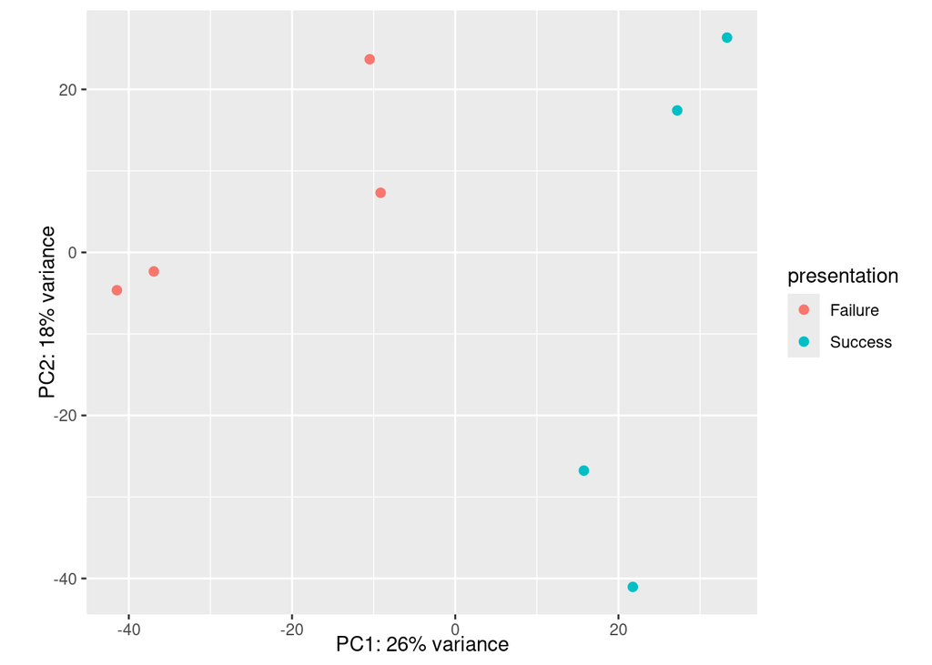

```r
vstcounts <- vst(DESeq_dds, blind = FALSE)
PCAplot <- plotPCA(vstcounts, intgroup=c("presentation"), returnData=TRUE)
percentVar <- round(100 * attr(PCAplot, "percentVar"))
options(bitmapType="cairo")
#use ggplot to edit
HCCpca <- ggplot(PCAplot, aes(PC1, PC2, color=presentation)) +
  geom_point(size=2) +
  xlab(paste0("PC1: ",percentVar[1],"% variance")) +
  ylab(paste0("PC2: ",percentVar[2],"% variance")) +
  coord_fixed()
HCCpca
```

The PCA plot is saved as RDS file.

```r
#saveRDS(HCCpca, file = "PCAplot.rds")
```

## Heatmap visualization

### Loading data

The previously written .csv files are loaded as newly named objects.

```r
#load DEG file
all_matrix <- read.csv("HCC_Success_vs_Failure_DEG.csv", header = TRUE)
all_matrix <- data_frame(all_matrix)
```

Dataframe for the data required for heatmap visualization is loaded. Gene symbols are altered in consideration of multiple gene IDs matching to the same symbol.

```r
#create dataframe with only sample columns from DEG dataframe
heatmap_matrix <- dplyr:::select.data.frame(all_matrix,symbol, HCC_1:HCC_52)

#change duplicated gene symbols
uq_symbol_names <- make.names(heatmap_matrix[[1]], unique = T)
heatmap_matrix <- dplyr::select(heatmap_matrix, -symbol)
heatmap_matrix$symbol <- uq_symbol_names

#make gene symbols the row names
heatmap_matrix <- data.frame(heatmap_matrix, row.names = 9)

head(heatmap_matrix)
```

```
##             HCC_1     HCC_125   HCC_101   HCC_109   HCC_118    HCC_25
## FGR    311.714844  432.940303  496.1685  116.5603 1580.7481 1171.2607
## FUCA2 3629.997725 2100.955702 2472.4329 2329.5875 3829.8064 5018.0484
## CFTR     4.353559    4.426792    0.0000    0.0000  203.5751    0.0000
## MCUB   111.451117  202.747095  215.2867  229.0734  444.4587  271.7631
## ABCB4 2133.244046 1781.341286 2485.8884 2452.6233  759.1484  506.2066
## RALA  1100.579785 1284.655172  750.1395  863.6796 1629.4115 2245.8733
##            HCC_10     HCC_52
## FGR    912.755799  3599.6708
## FUCA2 6954.702981 10808.1933
## CFTR     5.223209   312.9786
## MCUB   588.916831  1338.7137
## ABCB4  919.284810   326.3323
## RALA  1943.033803  2197.5269
```

Save/load heatmap_matrix as RDS file

```r
#saveRDS(heatmap_matrix, file = "heatmap_matrix.rds")
# load RDS file of dds if necessary
heatmap_matrix <- readRDS("heatmap_matrix.rds")
```

Annotation file for data is loaded.

```r
#load annotation file
heatmap_meta <- read.csv("HCCSuccesvsFailure_anno.csv", header = TRUE)
```

### Set up parameters for pheatmap

The row names are changed to the sample names within annotation file.

```r
#change row names
row.names(heatmap_meta) <- heatmap_meta$samplename
```

Select only the conditions to be included.

```r
#select on the presentation column
heatmap_meta <- dplyr::select(heatmap_meta, presentation)
```

Save/load heatmap_meta as RDS file

```r
#saveRDS(heatmap_meta, file = "heatmap_meta.rds")
# load RDS file if necessary
heatmap_meta <- readRDS("heatmap_meta.rds")
```

Colors are assigned to the heatmap expression values.

```r
#expression value colors range from green to red
heatmap_colors <- colorRampPalette(colors = c("green", "black", "red"))(30)
#rev(brewer.pal(10, "RdBu"))
```

```r
#group colors are assigned red and blue
ann_colors <- list(presentation=c(Success="#fd0000", Failure="#0049bb"))
```

## Plotting with `pheatmap`

The heatmap is plotted with additional major arguments.

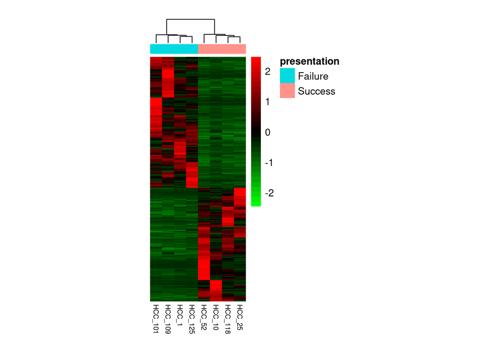

```r
HCC_heatmap <- as.ggplot(pheatmap(heatmap_matrix,
         color = heatmap_colors,
         annotation_col = heatmap_meta,
         clustering_method = 'ward.D',
         show_colnames = T,
         show_rownames = F,
         scale = "row",
         annotation_names_col = F,
         fontsize_col = 7,
         cellwidth = 12,
         cellheight = 0.25,
         treeheight_row = 0,
         treeheight_col = 20,

         ))
```

The heatmap plot is saved as a RDS file.

```r
#saveRDS(HCC_heatmap, file = "HCC_heatmap.rds")
```

## Figures for Biological Signifcance

### Set up gene lists

The background gene set is prepared prior to creating gene list.

```r
#get the log2 fold change
original_gene_list <- all_matrix$log2FoldChange

#name the vector
names(original_gene_list) <- all_matrix$input_id

#omit any NA values
background_gene_list<-na.omit(original_gene_list)

# sort the list in decreasing order
background_gene_list = sort(background_gene_list, decreasing = TRUE)

head(background_gene_list)
```

```
## ENSG00000172016 ENSG00000174358 ENSG00000126890 ENSG00000079112 ENSG00000106541
##       12.952985       12.082459       11.984914       10.790671       10.164150
## ENSG00000166206
##        9.751104
```

Data is prepared for significant gene set.

```r
# Extract significant results based on padj
sig_genes_df = subset(all_matrix, padj < 0.05)

#filter using log2FC
sig_genes <- sig_genes_df$log2FoldChange

# Name the vector
names(sig_genes) <- sig_genes_df$input_id

# omit NA values
sig_genes <- na.omit(sig_genes)

# significant results based on log2foldchange
sig_genes <- names(sig_genes)[abs(sig_genes) > 1]
head(sig_genes)
```

```
## [1] "ENSG00000000938" "ENSG00000001036" "ENSG00000001626" "ENSG00000005059"
## [5] "ENSG00000005471" "ENSG00000006451"
```

enrichGO object is created.

```r
go_enrich <- enrichGO(gene = sig_genes,
                      universe = background_gene_list,
                      OrgDb = org.Hs.eg.db,
                      keyType = 'ENSEMBL',
                      readable = T,
                      ont = "BP",
                      pvalueCutoff = 0.05,
                      qvalueCutoff = 0.05)
```

enrichGO object is saved/loaded as RDS.

```r
#saveRDS(go_enrich, file = "go_enrich.rds")
#load RDS if necessary
go_enrich <- readRDS("go_enrich.rds")
```

### Visualize GO Pathways

The 10 most enriched biological processes are displayed in a bargraph

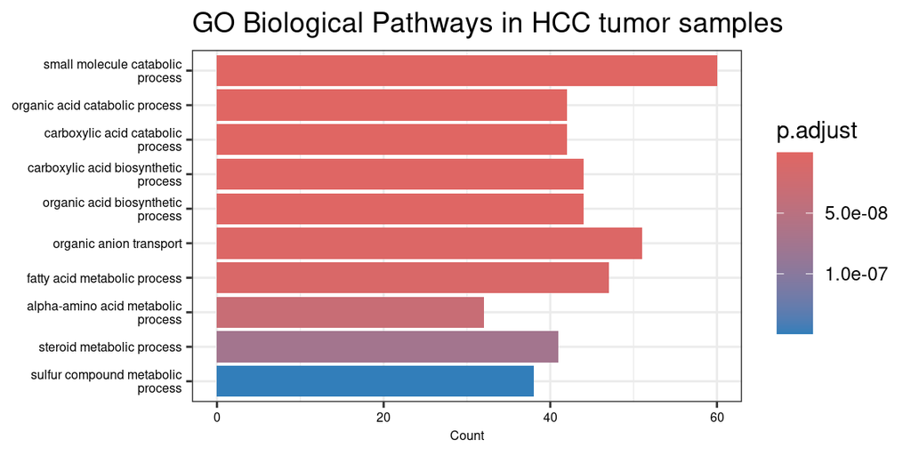

```r
bp_barplot <- as.ggplot(barplot(go_enrich, showCategory = 10, title = "GO Biological Pathways in HCC tumor samples" , font.size = 6  ))
bp_barplot
```

Save biological pathways barplot as RDS file

```r
#saveRDS(bp_barplot, file = "bp_barplot.rds")
```

### Data is continued to be prepared for additional visualization

Results are extracted into a table

```r
## Output results from enirchgo in a table
cluster_summary <- data.frame(go_enrich)
write.csv(cluster_summary, "clusterProfiler_HCC.csv")

head(cluster_summary)
```

```
##                    ID                          Description GeneRatio   BgRatio
## GO:0044282 GO:0044282     small molecule catabolic process    60/758 403/21261
## GO:0016054 GO:0016054       organic acid catabolic process    42/758 276/21261
## GO:0046395 GO:0046395    carboxylic acid catabolic process    42/758 276/21261
## GO:0046394 GO:0046394 carboxylic acid biosynthetic process    44/758 361/21261
## GO:0016053 GO:0016053    organic acid biosynthetic process    44/758 364/21261
## GO:0015711 GO:0015711              organic anion transport    51/758 488/21261
##                  pvalue     p.adjust       qvalue
## GO:0044282 3.750416e-21 1.839204e-17 1.605178e-17
## GO:0016054 1.693721e-15 2.768670e-12 2.416376e-12
## GO:0046395 1.693721e-15 2.768670e-12 2.416376e-12
## GO:0046394 1.126820e-12 1.381481e-09 1.205697e-09
## GO:0016053 1.500622e-12 1.471810e-09 1.284533e-09
## GO:0015711 6.705804e-12 5.480877e-09 4.783474e-09
##                                                                                                                                                                                                                                                                                                          …
## GO:0044282 HSD17B6/OAT/PFKP/PKM/ABCB11/ACACB/ECHDC1/UPB1/MLYCD/QPRT/IL4…
## GO:0016054                                                                                                             OAT/ABCB11/ACACB/ECHDC1/MLYCD/QPRT/IL4I1/SULT2A1/ASPA/DAO/AL…
## GO:0046395                                                                                                             OAT/ABCB11/ACACB/ECHDC1/MLYCD/QPRT/IL4I1/SULT2A1/ASPA/DAO/AL…
## GO:0046394                                                                                          MLXIPL/BCAT1/OAT/ACSM2B/ABCB11/PTGS2/ACACB/SLC27A5/SCD/UPB1/…
## GO:0016053                                                                                          MLXIPL/BCAT1/OAT/ACSM2B/ABCB11/PTGS2/ACACB/SLC27A5/SCD/UPB1/…
## GO:0015711           CFTR/ABCB4/SLC11A1/SLC2A3/ABCB11/PTGS2/SLC27A5/ABCC6/SLCO4A1…
##            Count
## GO:0044282    60
## GO:0016054    42
## GO:0046395    42
## GO:0046394    44
## GO:0016053    44
## GO:0015711    51
```

The identification is converted to entrezID and duplicates are removed.

```r
# Convert gene IDs
ids<-bitr(names(original_gene_list),
          fromType = "ENSEMBL",
          toType = "ENTREZID",
          OrgDb="org.Hs.eg.db")

# remove duplicate IDS
dedup_ids = ids[!duplicated(ids[c("ENSEMBL")]),]
```

A new dataframe is created of only genes that were converted in previous step.

```r
# Create a new dataframe
entrez_df = all_matrix[all_matrix$input_id %in% dedup_ids$ENSEMBL,]

# Create a new column for entrezIDs
entrez_df <- merge(all_matrix, dedup_ids, by.x = "input_id", by.y = "ENSEMBL")

str(entrez_df)
```

```
## 'data.frame':    936 obs. of  20 variables:
##  $ input_id      : chr  "ENSG00000000938" "ENSG00000001036" "ENSG00000001626" "ENSG00000005059" ...
##  $ X             : int  1 2 3 4 5 6 7 8 9 10 ...
##  $ baseMean      : num  1077.7 4643 66.3 425.3 1420.5 ...
##  $ log2FoldChange: num  2.42 1.34 5.86 1.8 -1.82 ...
##  $ lfcSE         : num  0.627 0.442 1.757 0.576 0.42 ...
##  $ stat          : num  3.86 3.02 3.33 3.13 -4.33 ...
##  $ pvalue        : num  1.12e-04 2.49e-03 8.54e-04 1.76e-03 1.46e-05 ...
##  $ padj          : num  0.00678 0.04885 0.02495 0.03866 0.00161 ...
##  $ HCC_1         : num  311.71 3630 4.35 111.45 2133.24 ...
##  $ HCC_125       : num  432.94 2100.96 4.43 202.75 1781.34 ...
##  $ HCC_101       : num  496 2472 0 215 2486 ...
##  $ HCC_109       : num  117 2330 0 229 2453 ...
##  $ HCC_118       : num  1581 3830 204 444 759 ...
##  $ HCC_25        : num  1171 5018 0 272 506 ...
##  $ HCC_10        : num  912.76 6954.7 5.22 588.92 919.28 ...
##  $ HCC_52        : num  3600 10808 313 1339 326 ...
##  $ threshold     : logi  TRUE TRUE TRUE TRUE TRUE TRUE ...
##  $ symbol        : chr  "FGR" "FUCA2" "CFTR" "MCUB" ...
##  $ diffexpressed : chr  "Upregulated" "Upregulated" "Upregulated" "Upregulated" ...
##  $ ENTREZID      : chr  "2268" "2519" "1080" "55013" ...
```

This dataframe is saved/loaded as RDS.

```r
#saveRDS(entrez_df, file = "entrez_df.rds")
#load RDS if necessary
entrez_df <- readRDS("entrez_df.rds")
```

This dataframe is also written into a new file.

```r
write.csv(entrez_df, "HCC_Success_vs_Failure_entrezid.csv", row.names = TRUE)
```

### GSEA data preparation

Dataframe will be read in.

```r
gsea_data <- read.csv("HCC_Success_vs_Failure_entrezid.csv", header = TRUE)
#remove extra columns
gsea_data <- dplyr::select(gsea_data, -X)
gsea_data <- dplyr::select(gsea_data, -X.1)
```

Remove duplicates and insignificant values

```r
## Remove NA values
res_entrez <- dplyr::filter(gsea_data, ENTREZID != "NA")
## Remove entrez duplicates
res_entrez <- res_entrez[which(duplicated(res_entrez$ENTREZID) == F), ]
```

Fold changes will be extracted.

```r
## Extract foldchanges
foldchanges <- res_entrez$log2FoldChange

## Name fold change with the Entrez ID
names(foldchanges) <- res_entrez$ENTREZID

## Sort fold changes in decreasing order
foldchanges <- sort(foldchanges, decreasing = TRUE)
```

Save these as RDS files

```r
#saveRDS(foldchanges, "foldchanges.RDS")
foldchanges <- readRDS("foldchanges.RDS")
```

### Perform GSEA

```r
gseaKEGG <- gseKEGG(geneList = foldchanges,
                    organism = "hsa",
                    nPerm = 1000,
                    minGSSize = 20,
                    pvalueCutoff = 0.05,
                    verbose = FALSE)
```

Save this output as a RDS file

```r
#saveRDS(gseaKEGG, file = "gseaKEGG.RDS")
gseaKEGG <- readRDS("gseaKEGG.RDS")
```

Results are extracted.

```r
gseaKEGG_results <- gseaKEGG@result
```

GSEA plot visualization is performed.

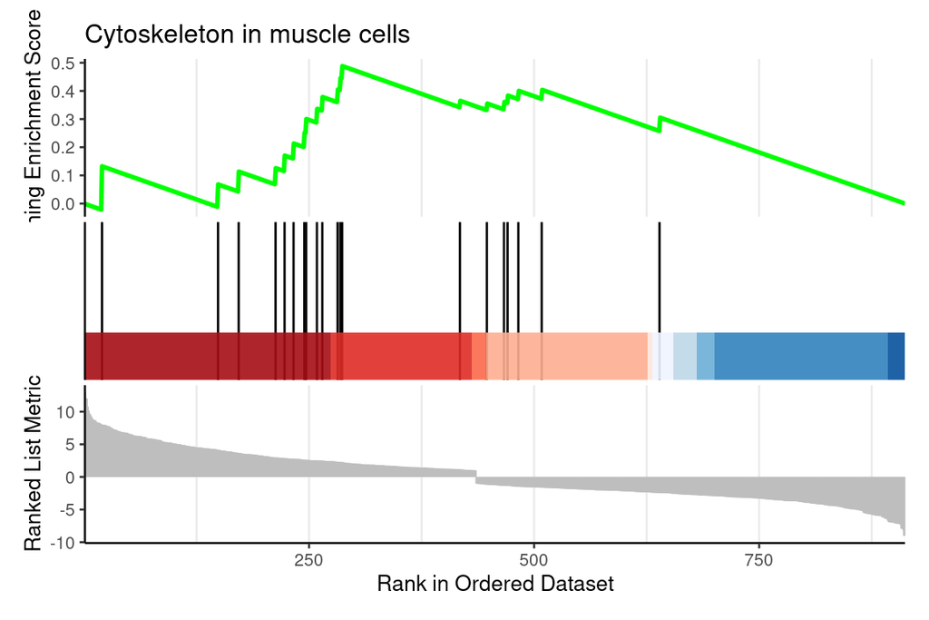

```r
enrich_gsea1 <- as.ggplot(gseaplot2(gseaKEGG,
                         title = gseaKEGG_results$Description[1],
                         geneSetID = 1,
                         rel_heights = 2, base_size = 10))
enrich_gsea1
```

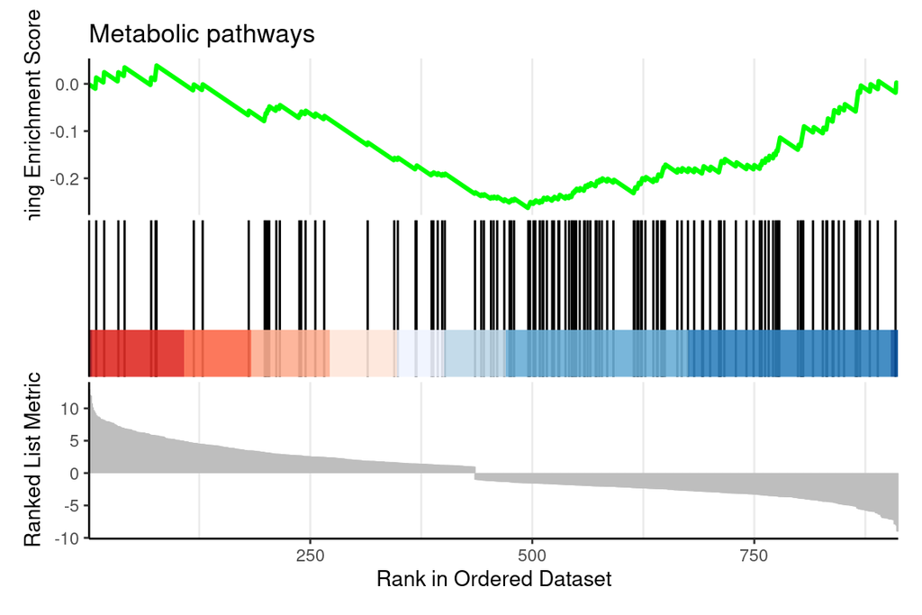

```r
enrich_gsea2 <- as.ggplot(gseaplot2(gseaKEGG,
                         title = gseaKEGG_results$Description[2],
                         geneSetID = 2,
                         rel_heights = 2, base_size = 10))
enrich_gsea2
```

GSEA plots are saved as RDS files

```r
#saveRDS(enrich_gsea1, file = "GSEA_1.rds")
#saveRDS(enrich_gsea2, file = "GSEA_2.rds")
```

### Investigate MSigDB gene sets

Download MSigDB gene sets from human category chemical and genetic perturbations

```r
CGP_gene_sets <- msigdbr(species = "human", category = "C2",
                            subcategory = "CGP") %>%
  dplyr::select(gs_name, entrez_gene)
head(CGP_gene_sets)
```

```
## # A tibble: 6 × 2
##   gs_name                  entrez_gene
##   <chr>                          <int>
## 1 ABBUD_LIF_SIGNALING_1_DN       79026
## 2 ABBUD_LIF_SIGNALING_1_DN         214
## 3 ABBUD_LIF_SIGNALING_1_DN       91369
## 4 ABBUD_LIF_SIGNALING_1_DN        8289
## 5 ABBUD_LIF_SIGNALING_1_DN         594
## 6 ABBUD_LIF_SIGNALING_1_DN      146556
```

Save gene sets in RDS file.

```r
#saveRDS(CGP_gene_sets, file= "CGP_gene_sets.rds")
CGP_gene_sets <- readRDS("CGP_gene_sets.rds")
```

Run GSEA on this.

```r
msig_CGP_GSEA <- GSEA(foldchanges, TERM2GENE = CGP_gene_sets, verbose = FALSE)
```

Save as a RDS file

```r
#saveRDS(msig_CGP_GSEA, "msig_CGP_GSEA.rds")
msig_CGP_GSEA <- readRDS("msig_CGP_GSEA.rds")
```

Extract GSEA results

```r
gseaCGP_results <- msig_CGP_GSEA@result
# Write to file
write.csv(gseaCGP_results, "gseaCGP_results.csv", quote=F)
#View(gseaGOBP_results)
```

Compare to gene sets identified by literature.

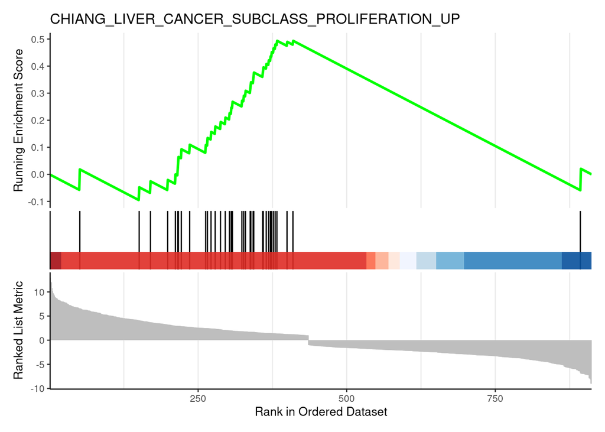

```r
## gsea plot for single pathway
prol_GSEA <- as.ggplot(gseaplot2(msig_CGP_GSEA, title = 'CHIANG_LIVER_CANCER_SUBCLASS_PROLIFERATION_UP', geneSetID = 'CHIANG_LIVER_CANCER_SUBCLASS_PROLIFERATION_UP', base_size = 10))
prol_GSEA
```

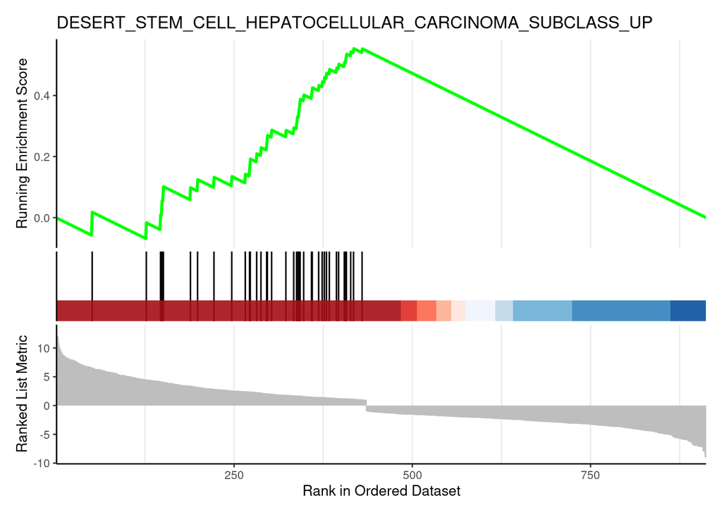

```r
## gsea plot for single pathway
HCC_GSEA <- as.ggplot(gseaplot2(msig_CGP_GSEA, title = 'DESERT_STEM_CELL_HEPATOCELLULAR_CARCINOMA_SUBCLASS_UP', geneSetID = 'DESERT_STEM_CELL_HEPATOCELLULAR_CARCINOMA_SUBCLASS_UP', base_size = 10))
HCC_GSEA
```

Save as RDS files

```r
saveRDS(prol_GSEA, file = "prol_GSEA.rds")
saveRDS(HCC_GSEA, file = "HCC_GSEA.rds")
```

## Create a multipanel figure

Reload individual figures.

```r
heatmap <- readRDS("HCC_heatmap.rds")
pca <- readRDS("PCAplot.rds")
bp_bar <- readRDS("bp_barplot.rds")
gsea_1 <- readRDS("GSEA_1.rds")
gsea_2 <- readRDS("GSEA_2.rds")
prol_GSEA <- readRDS("prol_GSEA.rds")
HCC_GSEA <- readRDS("HCC_GSEA.rds")
```

Cowplot is used to combine separate figures.

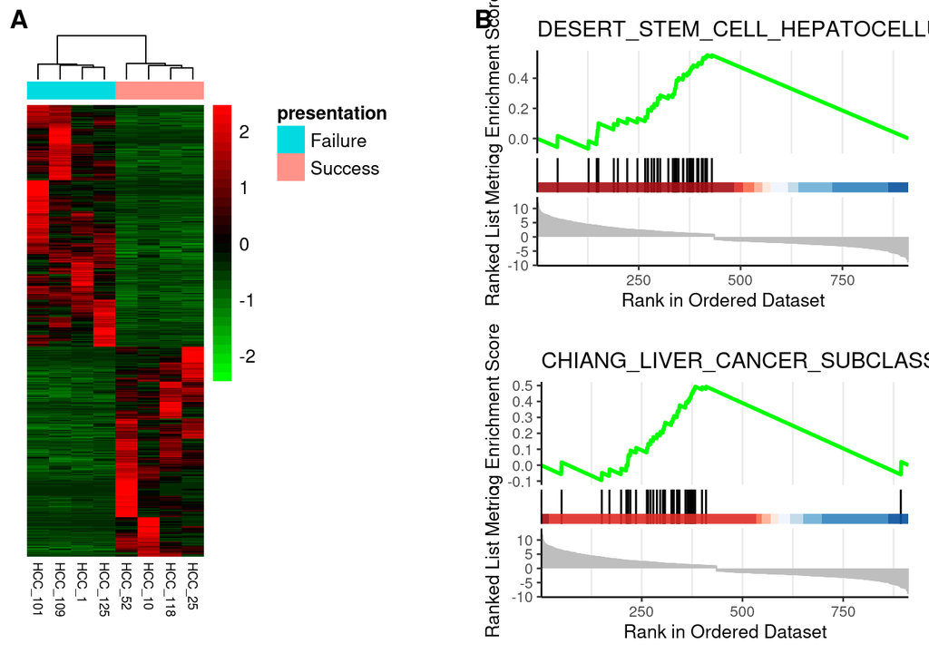

```r
#for orginal figure
Fig1A <- plot_grid(heatmap, labels = "A")
Fig1B <- plot_grid(HCC_GSEA, prol_GSEA, labels = "B", nrow = 2)
orig_fig <- plot_grid(Fig1A, Fig1B, align = "hv")
ggsave(filename = "original_figure.png",
       plot = orig_fig,
       units = "in",
       width = 15,
       height = 6,
       dpi = 300)
orig_fig
```

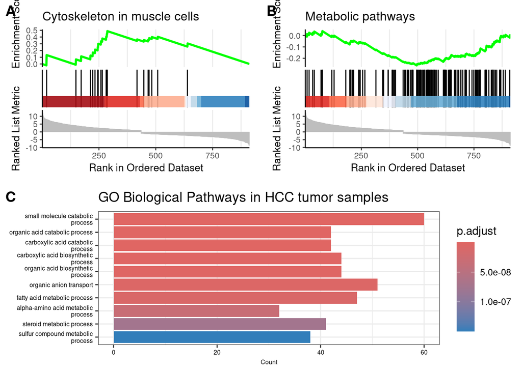

```r
#additional figure
FigAB <- plot_grid(gsea_1, gsea_2, labels = c("A","B"))
FigC <- plot_grid(bp_bar, labels = "C")
comb_fig <- plot_grid(FigAB,FigC, nrow = 2)
ggsave(filename = "additional_figure.png",
       plot = comb_fig,
       units = "in",
       width = 5,
       height = 6,
       dpi = 300)
comb_fig
```

Save each individual figures as their own png files

```r
ggsave(filename = "heatmap.png",
       plot =Fig1A,
       units = "in",
       width = 5,
       height = 6,
       dpi = 300)
ggsave(filename = "lit_GSEA.png",
       plot = Fig1B,
       units = "in",
       width = 12,
       height = 6,
       dpi = 300)
ggsave(filename = "add_GSEA.png",
       plot = FigAB,
       units = "in",
       width = 10,
       height = 6,
       dpi = 300)
ggsave(filename = "bp_bar.png",
       plot = FigC,
       units = "in",
       width = 8,
       height = 6,
       dpi = 300)
ggsave(filename = "PCA.png",
       plot = pca,
       units = "in",
       width = 8,
       height = 6,
       dpi = 300)
```